# Taller 03. Visualización de datos con ggplot2

2023-09-13

## 1. Introducción

En este taller aprenderemos el uso del paquete *ggplot2*, un paquete de R basado en la gramática de gráficos que permite visualizar datos de una manera consistente y estructurada. Para hacer más versátil su uso, se recomienda conocer el funcionamiento del paquete dplyr y el uso de tuberías (pipes `%>%`). *ggplot2* no está contenido en la librería tidyverse. Por eso, hay que instalarlo de forma separada. *tidiverse* sí incluye otros paquetes como dplyr que, a su vez, incluye los pipes (`%>%`). Para más detalles sobre *tidyverse* puede ir al Taller de Introducción a R y RStudio.

### 1.1. Conceptos básicos a desarrollar

En esta práctica se desarrollarán los siguientes conceptos:

- Gramática de gráficos
- Visualización de datos

### 1.2. Librerías necesarias para el taller

Por favor cargue las siguientes librerías

```r
library(knitr)
library(tidyverse)
library(lubridate)
library(ggplot2)
```

### 1.3. Objetivos

- Reconocer las funciones que componen el paquete *ggplot2*.
- Realizar gráficos básicos con la estructura de *ggplot2*.

## 2. Gramática de gráficos

*ggplot2* recibe su nombre precisamente de la abreviación del término *gramática de gráficos* (gg). La *gramática de los gráficos* se refiere a un enfoque conceptual propuesto y desarrollado por Leland Wilkinson para la creación de gráficos, el cual sirvió como base para el desarrollo de *ggplot2* a manos de Hadley Wickham. La gramática de los gráficos proporciona un marco conceptual para pensar sobre cómo construir y entender visualizaciones de datos de una manera coherente y estructurada. En términos simples, la gramática de los gráficos descompone un gráfico en sus componentes fundamentales y define cómo se combinan estos componentes para representar datos.

Estos componentes básicos son:

1. **Datos (Data):** representan los datos que queremos visualizar. Puede ser una tabla de datos (data.frame) en R u otra fuente de datos.
2. **Estética (Aesthetics):** definen cómo se mapean los atributos de los datos a propiedades visuales del gráfico, como posición en el eje X (`x`), posición en el eje Y (`y`), color, forma, tamaño, etc. Esto se especifica mediante la función `aes()` en `ggplot2`.
3. **Geometría (Geometry):** representa la forma en que los datos se visualizan en el gráfico, como puntos, líneas, barras, áreas, etc. Cada tipo de gráfico tiene su función correspondiente en ggplot2, como `geom_point()` para un gráfico de dispersión o `geom_bar()` para un gráfico de barras.
4. **Escala (Scale):** define cómo se mapean los valores de los datos a los valores visuales, como el rango de colores o el rango de los ejes. ggplot2 ajusta automáticamente las escalas, pero también puedes personalizarlas con funciones como `` scale_log10(),``scale_x_continuous() `` o `scale_color_manual()`.
5. **Facetas (Facets):** permiten dividir los datos en subconjuntos y mostrarlos en paneles múltiples (facetas) según ciertas variables. Puedes usar `facet_wrap()` o `facet_grid()` en *ggplot2* para implementar esta funcionalidad.
6. **Temas (Themes):** controlan la apariencia visual general del gráfico, como títulos, etiquetas de ejes, fondos, etc. Puedes personalizar el tema con la función `theme()` en `ggplot2`.

Ahora, veremos cada uno de los componentes para realizar gráficos de datos con *ggplot2*.

## 3. Datos para ggplot2

Siempre se requiere una tabla de datos (una estructura con filas y columnas) para poder ser usada en la estética de los gráficos. Previo al uso de *ggplot2*, suele ser necesario realizar un proceso de limpieza y organización de los datos. Para este taller usaremos una base de datos limpia, que nos permita hacer las visualizaciones sin la necesidad de pre-procesar los datos.

La tabla de datos para este taller puede encontrarla en: https://github.com/TRACE-LAC/TRACE-LAC-data/blob/main/otros/muestra_covid.RDS?raw=true.

Si ya cuenta con los datos en su computador, puede ejecutar los el siguiente comando

```r
covid19 <- readRDS("data/muestra_covid.RDS")
```

Una vez obtenida la tabla de datos es necesario explorar sus datos para conocer su estado actual.

```r
glimpse(covid19)
```

```
## Rows: 10,000
## Columns: 23
## $ fecha_reporte_web            <dttm> 2021-06-29, 2021-04-23, 2021-06-07, 2021…
## $ id_de_caso                   <dbl> 4208058, 2737390, 3576919, 2944674, 23005…
## $ fecha_de_notificacion        <dttm> 2021-06-15, 2021-04-19, 2021-05-24, 2021…
## $ codigo_divipola_departamento <dbl> 68, 5, 68, 11, 13001, 54, 66, 5, 81, 25, …
## $ nombre_departamento          <chr> "SANTANDER", "ANTIOQUIA", "SANTANDER", "B…
## $ codigo_divipola_municipio    <dbl> 68001, 5001, 68001, 11001, 13001, 54001, …
## $ nombre_municipio             <chr> "BUCARAMANGA", "MEDELLIN", "BUCARAMANGA",…
## $ edad                         <dbl> 39, 73, 15, 45, 22, 20, 45, 48, 71, 24, 3…
## $ sexo                         <chr> "F", "F", "M", "F", "M", "M", "M", "F", "…
## $ tipo_de_contagio             <chr> "Relacionado", "Comunitaria", "Relacionad…
## $ ubicacion_del_caso           <chr> "Casa", "Casa", "Casa", "Casa", "Casa", "…
## $ estado                       <chr> "Leve", "Leve", "Leve", "Leve", "Leve", "…
## $ recuperado                   <chr> "Recuperado", "Recuperado", "Recuperado",…
## $ fecha_de_inicio_de_sintomas  <dttm> 2021-06-10, 2021-04-16, 2021-05-19, 2021…
## $ fecha_de_muerte              <date> NA, NA, NA, NA, NA, NA, NA, NA, NA, NA, …
## $ fecha_de_diagnostico         <dttm> 2021-06-26, 2021-04-20, 2021-06-04, 2021…
## $ fecha_recuperacion           <dttm> 2021-06-30, 2021-04-30, 2021-06-08, 2021…
## $ tipo_de_recuperacion         <chr> "Tiempo", "Tiempo", "Tiempo", "Tiempo", "…
## $ pertenencia_etnica           <dbl> 6, 6, 6, 6, 6, 6, 6, 6, 6, 6, 6, 6, 6, 6,…
## $ nombre_del_grupo_etnico      <chr> NA, NA, NA, NA, NA, NA, NA, NA, NA, NA, N…
## $ fecha_nacimiento             <dbl> 1983, 1949, 2007, 1977, 2000, 2002, 1977,…
## $ retraso_notificacion         <dbl> 5, 3, 5, 12, 7, 4, 1, 4, 4, 1, 0, NA, 1, …
## $ tiempo_recuperacion          <dbl> 20, 14, 20, 19, 14, 14, 14, 14, 18, 213, …
```

Tras observar la estructura actual de la tabla de datos, se debe preguntar qué datos desea graficar.

## 4. Estética (Aesthetics)

En el contexto de la gramática de los gráficos, la estética (aesthetics) se refiere a cómo mapeamos los atributos de nuestros datos a propiedades visuales en el gráfico. Estas propiedades visuales pueden ser elementos tales como la posición en el eje X (`x`), la posición en el eje Y (`y`), el color, la forma, el tamaño, etc. Al mapear estos atributos podemos crear visualizaciones que nos permiten comprender y comunicar patrones y relaciones en los datos de manera efectiva.

En `ggplot2` la función principal para especificar la estética es `aes().` Aquí hay algunos ejemplos para ilustrar cómo usar la estética en `ggplot2`:

**Ejemplo 1: Gráfico de dispersión (Scatter plot)**

Supongamos que tenemos una tabla de que cuenta con las variables `x` e `y`. Queremos crear un gráfico de dispersión donde la variable `x` se mapea en el eje X y la variable `y` en el eje Y. Además, queremos que los puntos se coloreen según la variable `grupo`. Mediante la función `aes()` de *ggplot2* es posible asignar estas variables a los correspondientes atributos visuales del gráfico, como veremos en el ejemplo a continuación.

Consideremos la base `covid19` que cargamos anteriormente. Imagine que requiere un gráfico de dispersión que muestre la incidencia de casos por fecha de reporte desagregados por sexo. Primero organizamos los datos para lograr una tabla resumen con la información que queremos graficar:

```r
covid19_resumen <- covid19 %>%
  group_by(fecha_reporte_web, sexo) %>%
  summarise(casos = n())
```

Luego, podemos usar la estética de los gráficos de ggplot2 de la siguiente manera:

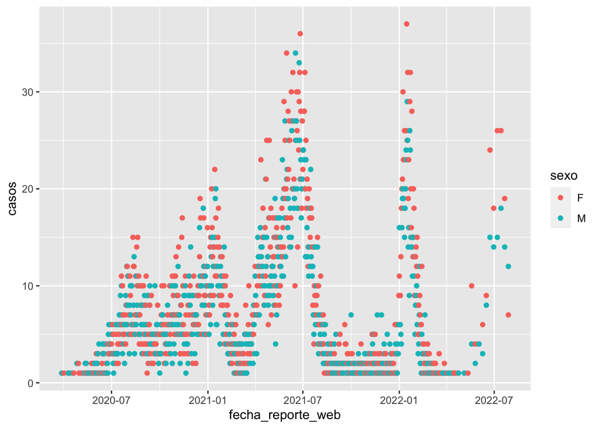

```r
ggplot(
  data = covid19_resumen,
  aes(x = fecha_reporte_web, y = casos, color = sexo)
  ) +
  geom_point()
```

## 5. Geometría (Geometry):

La geometría representa la forma en que los datos se visualizan en el gráfico; como puntos, líneas, barras, áreas, etc. Cada tipo de gráfico tiene su función correspondiente en `ggplot2`, como `geom_point()` para un gráfico de dispersión o `geom_bar()` para un gráfico de barras.

En la siguiente tabla se muestran algunos ejemplos de los distintos tipos de gráficos soportados por *ggplot2* con su correspondiente comando:

| **Tipo de gráfica** | **Geometría en ggplo2** |
| --- | --- |
| Gráfica de barras | geom_bar() |
| Gráfico de columnas | geom_col() |
| Histograma | geom_hist() |
| Gráfico de dispersión | geom_point() |
| Gráfico de dispersión con jitter | geom_jitter() |
| Gráfico de líneas | geom_line() |
| Gráfico de cajas y bigotes | geom_boxplot() |
| Gráfico de densidad | geom_density() |
| Gráfico de violín | geom_violin() |
| Mapa de calor | geom_heatmap() |
| Creación de mapas | geom_sf() |
| Línea de regresión | geom_smooth() |
| Gráfico de punto | geom_point() |

**Ejemplo 2: Gráfico de líneas**

Supongamos que queremos visualizar la evolución del número de casos de covid-19 a lo largo del tiempo. Para esto, primero debemos preparar la tabla que irá en el gráfico:

```r
covid19_fecha <- covid19 %>%
  group_by(fecha_reporte_web) %>%
  summarise(casos = n())
```

Una vez la tabla esté lista, procedemos a usar la geometría de *ggplot2*:

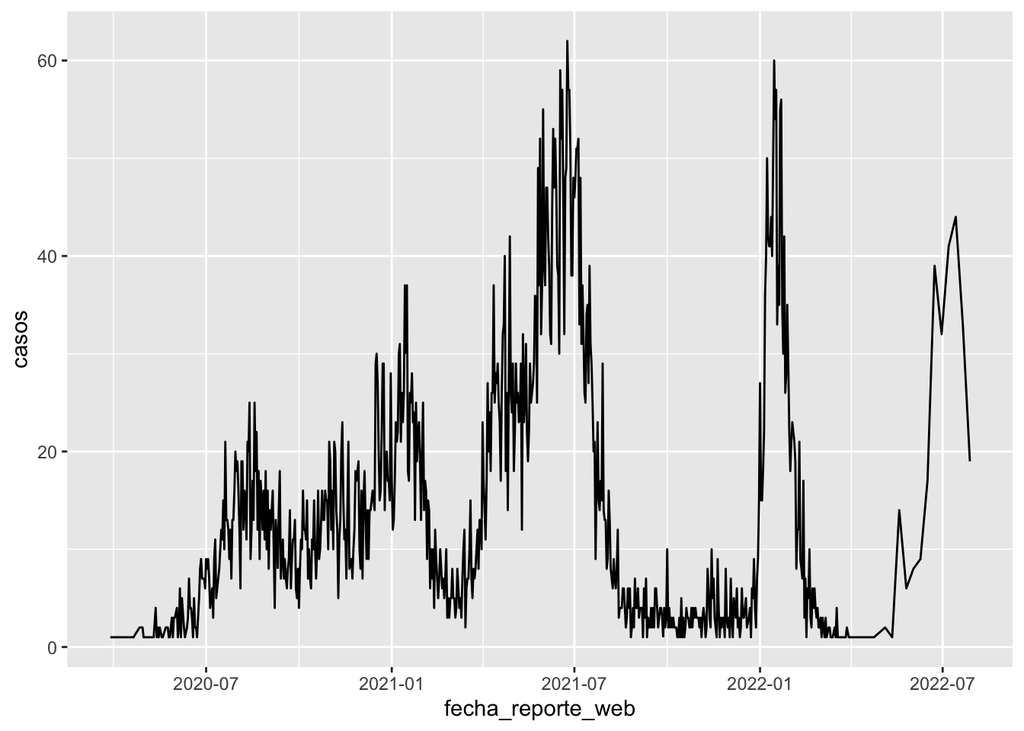

```r
ggplot(
  data = covid19_fecha,
  aes(x = fecha_reporte_web, y = casos)
  ) +
  geom_line()
```

**Ejemplo 3: Gráfico de barras**

Ahora, hagamos una visualización en forma de gráfico de barras del total de casos positivos por sexo:

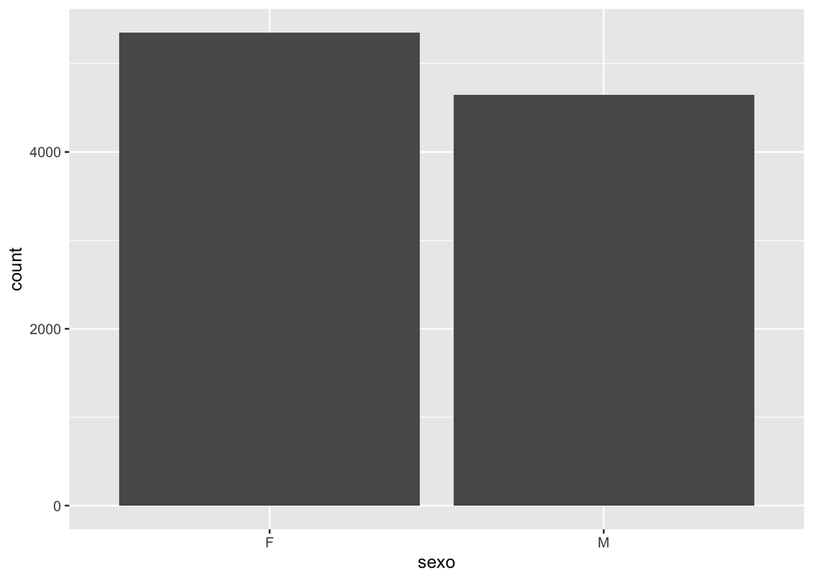

```r
ggplot(data = covid19) +
  geom_bar(aes(x = sexo))
```

En el ejemplo 3, se puede observar que ggplot2 automáticamente calcula el eje Y.

**Ejemplo 4. Gráfico de barras más complejo**

Primero vamos a preparar los datos en una tabla de datos que permita contar el número de casos por departamentos:

```r
covid19_depto <- covid19 %>%
  group_by(nombre_departamento) %>%
  summarise(casos = n())
```

Ahora, por medio de la geometría de ggplot, hacemos la visualización usando el argumento `stat = "identity"` que calcula la suma de la variable `y = casos` agrupando por la variable `x = nombre_departamento`:

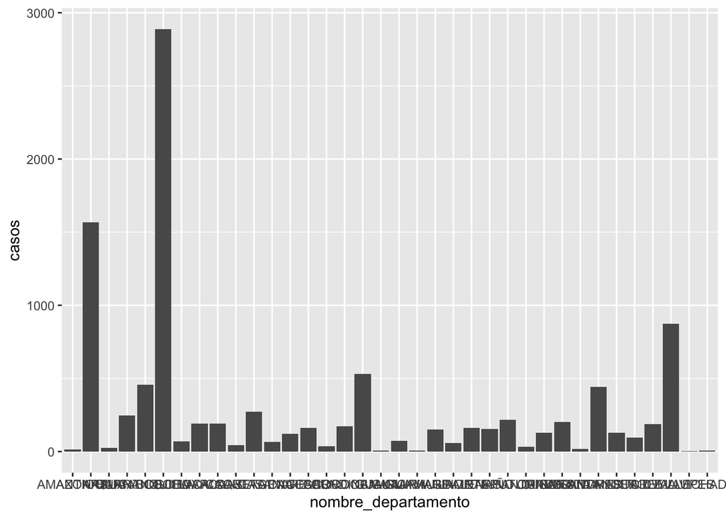

```r
ggplot(data = covid19_depto, aes(x = nombre_departamento, y = casos)) +
  geom_bar(stat = "identity")
```

Se puede notar que no es posible ver bien los nombres de los departamentos. Para solucionar este problema, una alternativa es dar la vuelta a los ejes, usando al final el comando `coord_flip`

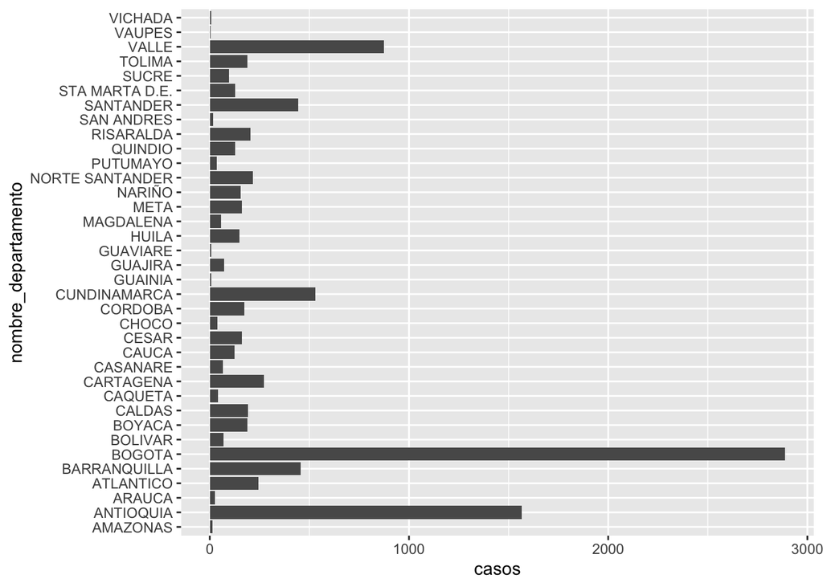

```r
ggplot(data = covid19_depto, aes(x = nombre_departamento, y = casos)) +
  geom_bar(stat = "identity") +
  coord_flip()
```

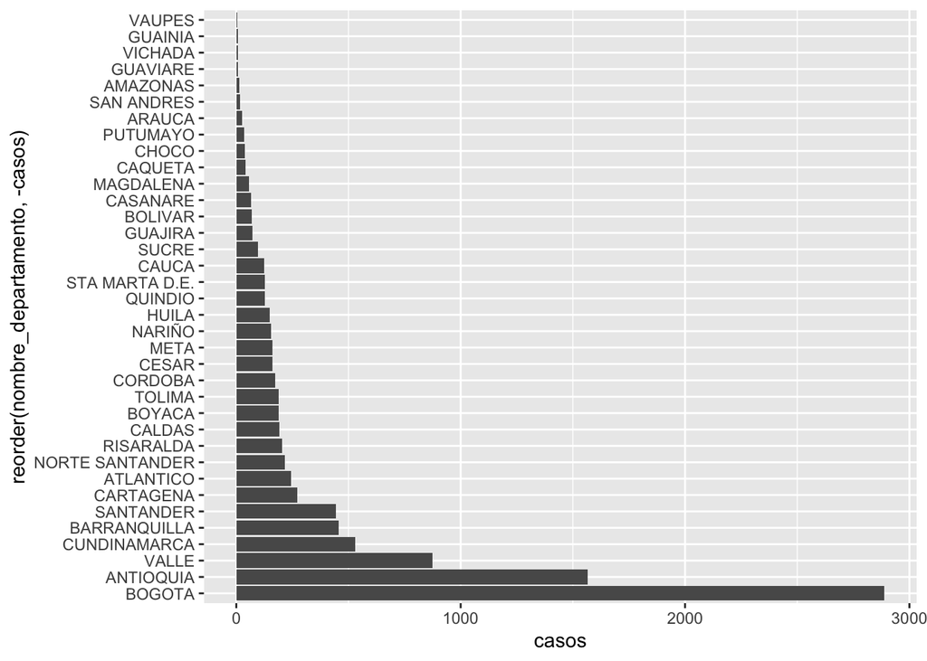

```r
ggplot(
  covid19_depto,
  aes(x = reorder(nombre_departamento, -casos), y = casos)
) +
  geom_bar(stat = "identity") +
  coord_flip()
```

*Pregunta ¿cómo produciría el mismo gráfico pero en orden descendente?*

## 6. Escala (Scale)

En la gramática de los gráficos, la escala se refiere a cómo se mapean los valores de los datos a los valores visuales en el gráfico; es decir, cómo se representan los datos en la visualización. La elección adecuada de las escalas es esencial para que los gráficos sean interpretables y precisos.

A continuación, veremos algunos ejemplos de cómo usar la escala en ggplot2 con el `data.frame` `covid19`.

Usamos exáctamente el mismo ejemplo anterior, pero en este caso al final agregamos la escala logarítmica *`scale_y_log10()`*

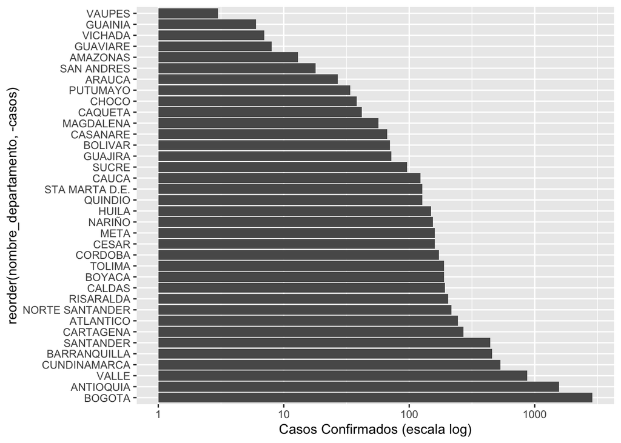

```r
ggplot(covid19_depto, aes(x = reorder(nombre_departamento, -casos), y = casos)) +
  geom_bar(stat = "identity") +
  coord_flip() +
  scale_y_log10(name = "Casos Confirmados (escala log)")
```

*Por favor describa, ¿qué pasó en el ejercicio 5? ¿cuál es la diferencia con el ejercicio 4?*

## 7. Facetas (Facets)

Las Facetas (Facets) en la gramática de los gráficos son una forma de dividir los datos en subconjuntos y representarlos en múltiples paneles dentro del mismo gráfico. Esto nos permite visualizar diferentes aspectos de los datos o comparar grupos de manera más efectiva. En `ggplot2`, podemos usar la función `facet_wrap()` o `facet_grid()` para implementar las facetas.

**Ejemplo 5. Gráfico con facet wrap**

Usando los datos de covid-19, vamos a representar la variable `tiempo_recuperación` en dos páneles por `sexo` usando `facet_wrap`.

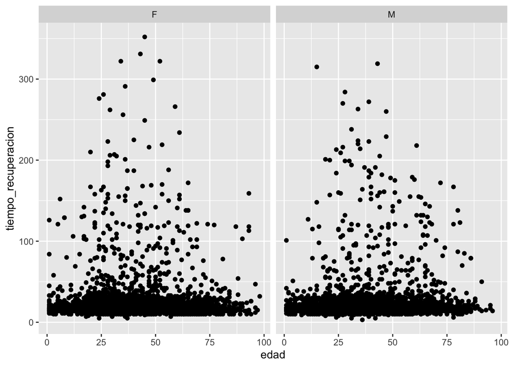

```r
ggplot(data = covid19, aes(x = edad, y = tiempo_recuperacion)) +
  geom_point() +
  facet_wrap(~sexo)
```

De acuerdo a lo aprendido anteriormente, intentemos que cada faceta quede de un color diferente, es decir, asignando color a la varible sexo. ¿cómo cambiaría el código? El gráfico que debe producir es el siguiente:

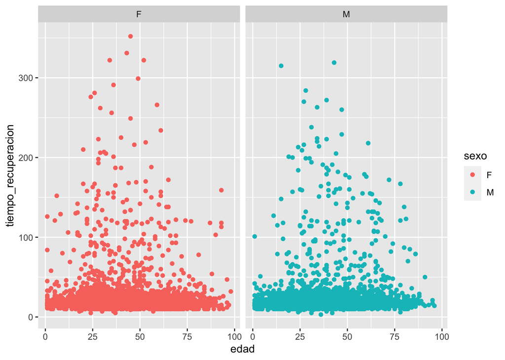

## 8. Tema (Theme)

En la gramática de los gráficos, el tema se refieren a la personalización de la apariencia visual general del gráfico, como los títulos, etiquetas de ejes, fondos, colores, tamaños de fuente, entre otros elementos. Con los temas, podemos mejorar la legibilidad y estética de los gráficos, asegurando que la información se comunique de manera efectiva y atractiva.

En `ggplot2`, podemos aplicar un tema predeterminado utilizando la función theme_gray(), pero también podemos personalizar cada aspecto visual mediante la función `theme()`. A continuación, proporcionamos algunos ejemplos de cómo utilizar los temas en *ggplot2* con la base de datos `covid19`.

Usando la misma gráfica anterior, comparemos dos temas: `theme_classic()` y `theme_dark()`. Describa en sus propias palabras las diferencias

**Ejemplo 6. Usando theme classic**

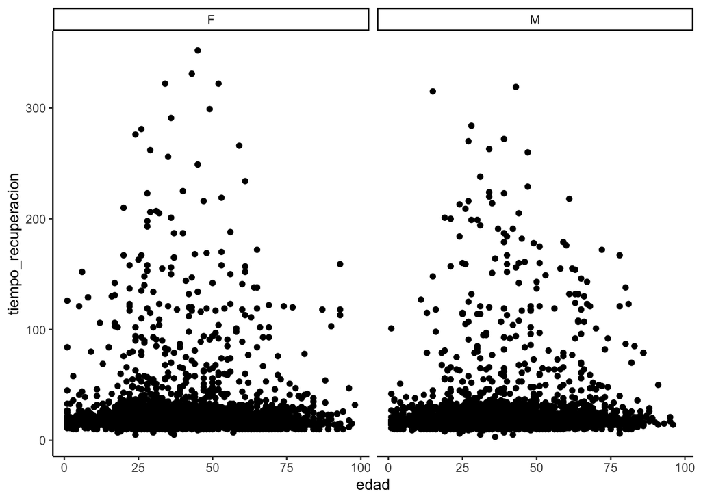

```r
ggplot(data = covid19, aes(x = edad, y = tiempo_recuperacion)) +
  geom_point() +
  facet_wrap(~sexo) +
  theme_classic()
```

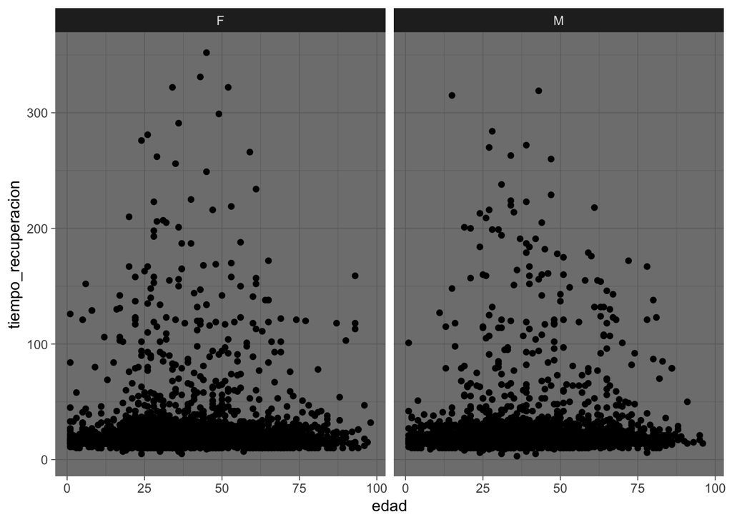

```r
ggplot(data = covid19, aes(x = edad, y = tiempo_recuperacion)) +
  geom_point() +
  facet_wrap(~sexo) +
  theme_dark()
```

Para revisar la lista de `theme()` que tiene disponible `ggplot2`, puede consultarse en https://ggplot2.tidyverse.org/reference/ggtheme.html

Finalmente, veamos un ejemplo de como modificar los themes manualmente.

**Ejemplo 8. Cambiando títulos, subtítulos y ejes**

Podemos usar comandos como `xlab`, `ylab` para cambiar los nombres de los ejes. Igualmente, comandos como `title` y `subtitle`.

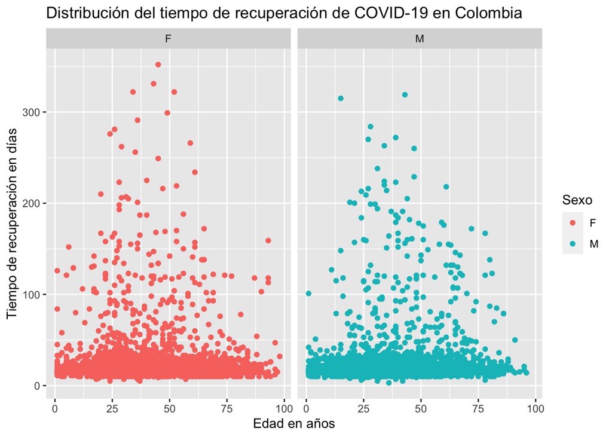

```r
ggplot(data = covid19, aes(x = edad, y = tiempo_recuperacion, colour = sexo)) +
  geom_point() +
  facet_wrap(~sexo) +
  labs(
    y = "Tiempo de recuperación en días", x = "Edad en años",
    colour = "Sexo",
    title = "Distribución del tiempo de recuperación de COVID-19 en Colombia"
  )
```

## 9. Reto

Usando la base de datos `covid19` con la que hemos trabajado, intentemos recrear el siguiente gráfico en `ggplot`:

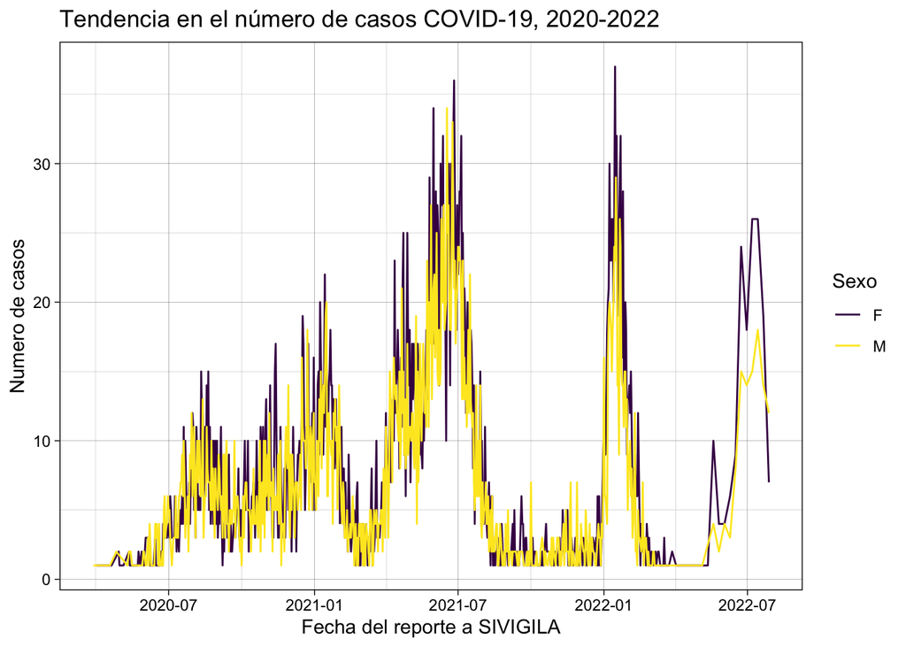

Hemos llegado al final de la práctica *ggplot2*. ¡Muchas gracias por su participación!

## Sobre este documento

*Contribuciones:* Zulma M. Cucunubá: primera versión